# Formulas and Model Families: mtcars II

Ray Nelson

29 March 2019

## Models

- Extract patterns from data
- Decompose variation into explained and unexplained
- Extract all possible information from data
- Achieve balance between explanatory power and simplicity

## Four functions will help us understand the subfamilies of linear models called:

- Analysis of Variance (ANOVA)
- Analysis of Covariance

```r
## Violin plot
violin_plot <- function(data_set, x, y) {
  x <- data_set[[x]]
  y <- data_set[[y]]
  tibble(x = x, y = y) %>%
    ggplot(aes(reorder(x, y, FUN = median), y)) +
    geom_violin(fill = "lightgreen") +
    geom_boxplot(width = 0.10, fill = "lightblue") +
    labs(title = "Violin Plot",
         x = "Categorical Explanatory Variable",
         y = "Response Variable")
}

## Relationship between response and explanatory
relationship <- function(data_set, x, y) {
  data_set %>%
    ggplot(aes_string(x, y)) +
    geom_point() +
    geom_smooth(method = "lm") +
    geom_smooth(colour = "red") +
    labs(title = "Relationship between response and explanatory variables",
         x = "Explanatory Variable",
         y = "Response Variable")
}

## main effects
graph_main_effects <- function(data_set, model, x, y) {
  data_set %>%
    add_predictions(model = model, var = "pred") %>%
    ggplot(aes_string(x = x, y = y, color = x)) +
    geom_point(show.legend = FALSE, position = "jitter") +
    geom_point(aes(y = pred), show.legend = FALSE, size = 5,
               color = "black", shape = 3,) +
    labs(
      title = "Visualization of different models.",
      x = "Explanatory Variable",
      y = "Response Variable"
    )
}

## Analysis of covariance
graph_predictions <- function(data_set, model, x, y, category) {
  data_set %>%
    add_predictions(model = model, var = "pred") %>%
    ggplot(aes_string(x = x, y = y, color = category)) +
    geom_point() +
    geom_line(aes(y = pred)) +
    labs(
      title = "Visualization of different models.",
      x = "Explanatory Variable",
      y = "Response Variable"
    )
}
```

### mtcars Data Set

```r
data(mtcars)
mtcars$vs <- factor(mtcars$vs, levels = c(0, 1), labels = c("v-shaped", "straight"))
mtcars$am <- factor(mtcars$am, levels = c(0, 1), labels = c("automatic", "manual"))
glimpse(mtcars)
```

```
## Observations: 32
## Variables: 11
## $ mpg  <dbl> 21.0, 21.0, 22.8, 21.4, 18.7, 18.1, 14.3, 24.4, 22.8, 19....
## $ cyl  <dbl> 6, 6, 4, 6, 8, 6, 8, 4, 4, 6, 6, 8, 8, 8, 8, 8, 8, 4, 4, ...
## $ disp <dbl> 160.0, 160.0, 108.0, 258.0, 360.0, 225.0, 360.0, 146.7, 1...
## $ hp   <dbl> 110, 110, 93, 110, 175, 105, 245, 62, 95, 123, 123, 180, ...
## $ drat <dbl> 3.90, 3.90, 3.85, 3.08, 3.15, 2.76, 3.21, 3.69, 3.92, 3.9...
## $ wt   <dbl> 2.620, 2.875, 2.320, 3.215, 3.440, 3.460, 3.570, 3.190, 3...
## $ qsec <dbl> 16.46, 17.02, 18.61, 19.44, 17.02, 20.22, 15.84, 20.00, 2...
## $ vs   <fct> v-shaped, v-shaped, straight, straight, v-shaped, straigh...
## $ am   <fct> manual, manual, manual, automatic, automatic, automatic, ...
## $ gear <dbl> 4, 4, 4, 3, 3, 3, 3, 4, 4, 4, 4, 3, 3, 3, 3, 3, 3, 4, 4, ...
## $ carb <dbl> 4, 4, 1, 1, 2, 1, 4, 2, 2, 4, 4, 3, 3, 3, 4, 4, 4, 1, 2, ...
```

## Type of transmission

### Differences in mpg conditioned on the transmission of the vehicle

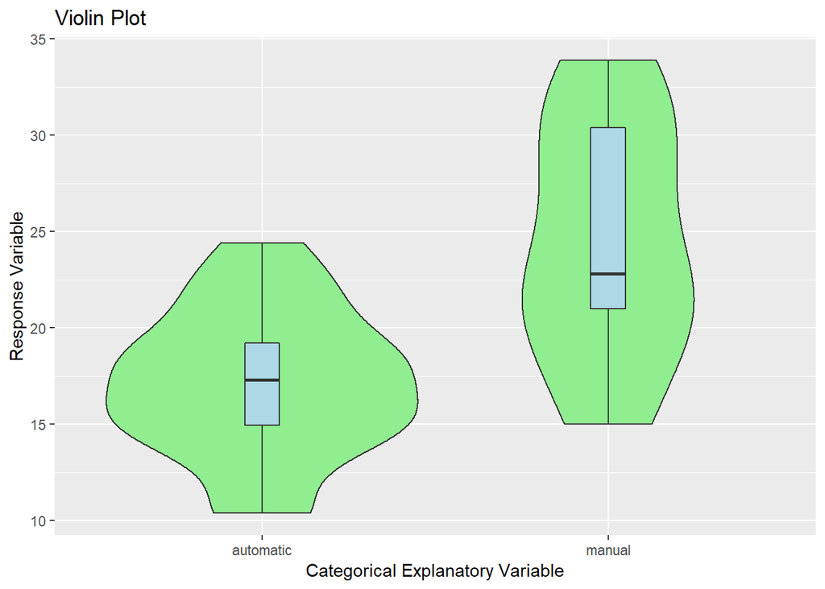

```r
violin_plot(mtcars, "am", "mpg")
```

### Simple model with transmission as a predictor of highway miles per gallon

```r
zero_slope <- lm(mpg ~ am, data = mtcars)
zero_slope %>%  summary()
```

```
##
## Call:
## lm(formula = mpg ~ am, data = mtcars)
##
## Residuals:
##     Min      1Q  Median      3Q     Max
## -9.3923 -3.0923 -0.2974  3.2439  9.5077
##
## Coefficients:
##             Estimate Std. Error t value Pr(>|t|)
## (Intercept)   17.147      1.125  15.247 1.13e-15 ***
## ammanual       7.245      1.764   4.106 0.000285 ***
## ---
## Signif. codes:  0 '***' 0.001 '**' 0.01 '*' 0.05 '.' 0.1 ' ' 1
##
## Residual standard error: 4.902 on 30 degrees of freedom
## Multiple R-squared:  0.3598, Adjusted R-squared:  0.3385
## F-statistic: 16.86 on 1 and 30 DF,  p-value: 0.000285
```

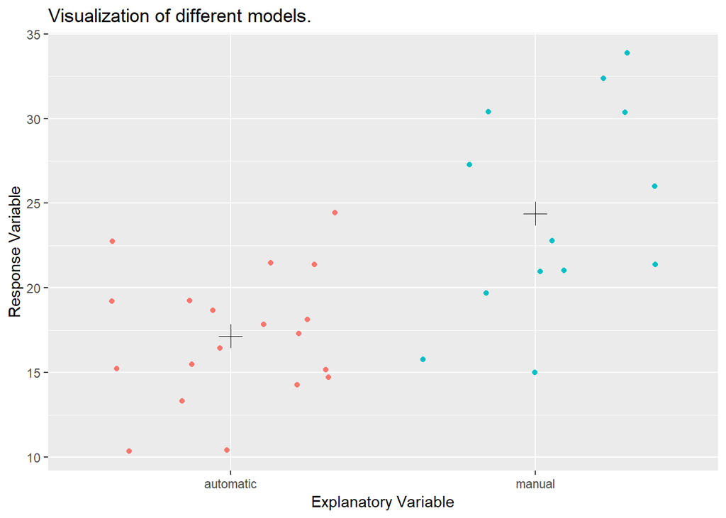

```r
graph_main_effects(mtcars, zero_slope, "am", "mpg")
```

### Does displacement have an effect on mileage?

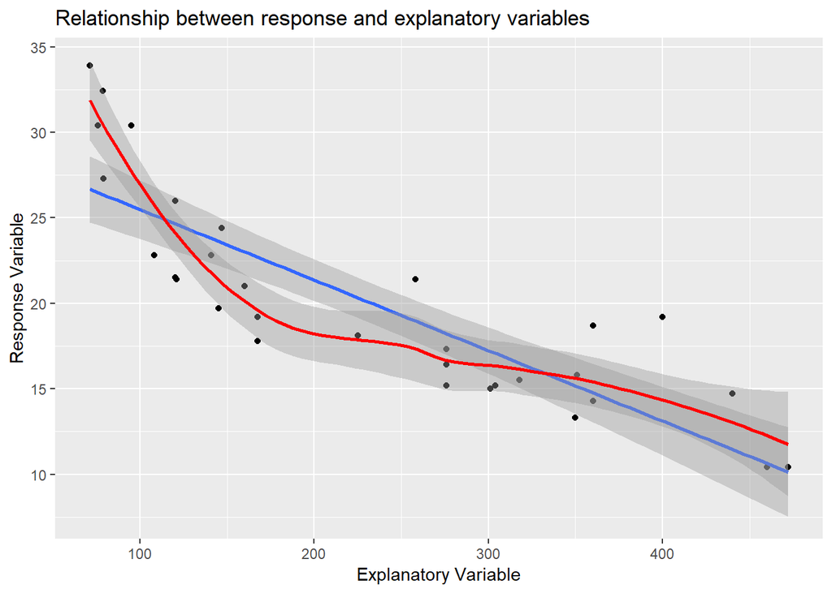

```r
relationship(mtcars, "disp", "mpg")
```

### Common slope for displacement and different intercepts based on transmission

```r
common_slope <- lm(mpg ~ disp + am, data = mtcars)
common_slope %>% summary()
```

```
##
## Call:
## lm(formula = mpg ~ disp + am, data = mtcars)
##
## Residuals:
##     Min      1Q  Median      3Q     Max
## -4.6382 -2.4751 -0.5631  2.2333  6.8386
##
## Coefficients:
##              Estimate Std. Error t value Pr(>|t|)
## (Intercept) 27.848081   1.834071  15.184 2.45e-15 ***
## disp        -0.036851   0.005782  -6.373 5.75e-07 ***
## ammanual     1.833458   1.436100   1.277    0.212
## ---
## Signif. codes:  0 '***' 0.001 '**' 0.01 '*' 0.05 '.' 0.1 ' ' 1
##
## Residual standard error: 3.218 on 29 degrees of freedom
## Multiple R-squared:  0.7333, Adjusted R-squared:  0.7149
## F-statistic: 39.87 on 2 and 29 DF,  p-value: 4.749e-09
```

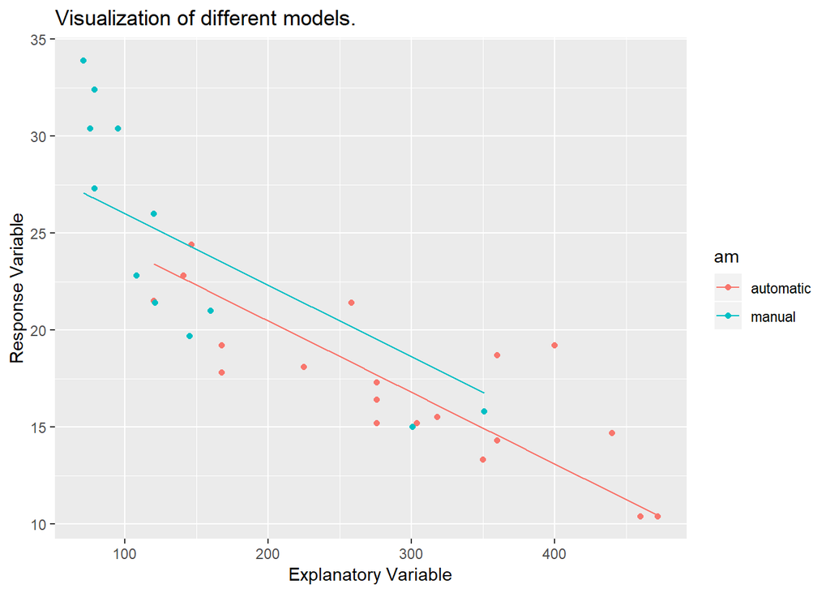

```r
graph_predictions(mtcars, common_slope, "disp", "mpg", "am")
```

### Different slopes and intercepts for each type of transmission

```r
different_slopes <- lm(mpg ~ disp + am + disp * am, data = mtcars)
different_slopes %>% summary()
```

```
##
## Call:
## lm(formula = mpg ~ disp + am + disp * am, data = mtcars)
##
## Residuals:
##     Min      1Q  Median      3Q     Max
## -4.6056 -2.1022 -0.8681  2.2894  5.2315
##
## Coefficients:
##                Estimate Std. Error t value Pr(>|t|)
## (Intercept)   25.157064   1.925053  13.068 1.94e-13 ***
## disp          -0.027584   0.006219  -4.435  0.00013 ***
## ammanual       7.709073   2.502677   3.080  0.00460 **
## disp:ammanual -0.031455   0.011457  -2.745  0.01044 *
## ---
## Signif. codes:  0 '***' 0.001 '**' 0.01 '*' 0.05 '.' 0.1 ' ' 1
##
## Residual standard error: 2.907 on 28 degrees of freedom
## Multiple R-squared:  0.7899, Adjusted R-squared:  0.7674
## F-statistic: 35.09 on 3 and 28 DF,  p-value: 1.27e-09
```

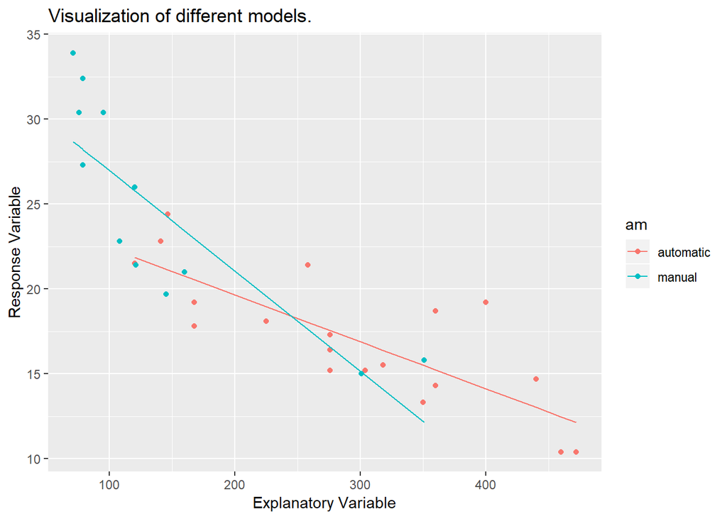

```r
graph_predictions(mtcars, different_slopes, "disp", "mpg", "am")
```

### As mentioned, we want to achieve an accurate but parsimonious model. Often times we have a trade-off between fit and simplicity. For this reason, we create measures that seek for optimal balance. These measures include:

- AIC
- AICc
- BIC
- Hannan-Quinn

All of these combine a measure of fit with a penalty for complexity. The measure of fit usually is related to an error measure which we want to make as small as possible. We also want to make the measure of complexity as small as possible.

If we add the error measure and the complexity measure together, we have our information criterion. We want this sum to be as small as possible. Adding a variable to a model probably reduces the error but increases the complexity. Keeping a variable in the model, therefore, involves determining whether the benefit from the reduction in the error is greater than the cost of the increase in complexity.

### Choose among all the variables and interactions using statistics and stepAIC

```r
big_model <- lm(mpg ~ cyl + disp + hp + drat + wt + qsec + vs + am, data = mtcars)
big_model %>% summary()
```

```
##
## Call:
## lm(formula = mpg ~ cyl + disp + hp + drat + wt + qsec + vs +
##     am, data = mtcars)
##
## Residuals:
##     Min      1Q  Median      3Q     Max
## -3.4735 -1.4664 -0.3822  1.2006  4.6215
##
## Coefficients:
##             Estimate Std. Error t value Pr(>|t|)
## (Intercept) 15.57313   16.38173   0.951  0.35167
## cyl         -0.27859    0.93475  -0.298  0.76835
## disp         0.01471    0.01203   1.223  0.23379
## hp          -0.02144    0.01623  -1.321  0.19947
## drat         0.81506    1.51009   0.540  0.59456
## wt          -3.94374    1.28744  -3.063  0.00551 **
## qsec         0.80976    0.65871   1.229  0.23139
## vsstraight   0.36836    2.01158   0.183  0.85631
## ammanual     2.79375    1.86824   1.495  0.14841
## ---
## Signif. codes:  0 '***' 0.001 '**' 0.01 '*' 0.05 '.' 0.1 ' ' 1
##
## Residual standard error: 2.544 on 23 degrees of freedom
## Multiple R-squared:  0.8678, Adjusted R-squared:  0.8218
## F-statistic: 18.87 on 8 and 23 DF,  p-value: 2.168e-08
```

```r
big_model %>% anova()
```

```
## Analysis of Variance Table
##
## Response: mpg
##           Df Sum Sq Mean Sq  F value    Pr(>F)
## cyl        1 817.71  817.71 126.3320 8.066e-11 ***
## disp       1  37.59   37.59   5.8081  0.024351 *
## hp         1   9.37    9.37   1.4478  0.241128
## drat       1  16.47   16.47   2.5441  0.124356
## wt         1  77.48   77.48  11.9696  0.002127 **
## qsec       1   3.95    3.95   0.6101  0.442699
## vs         1   0.13    0.13   0.0200  0.888635
## am         1  14.47   14.47   2.2362  0.148409
## Residuals 23 148.87    6.47
## ---
## Signif. codes:  0 '***' 0.001 '**' 0.01 '*' 0.05 '.' 0.1 ' ' 1
```

```r
big_model %>% stepAIC()
```

```
## Start:  AIC=67.2
## mpg ~ cyl + disp + hp + drat + wt + qsec + vs + am
##
##        Df Sum of Sq    RSS    AIC
## - vs    1     0.217 149.09 65.242
## - cyl   1     0.575 149.45 65.319
## - drat  1     1.886 150.76 65.598
## <none>              148.87 67.195
## - disp  1     9.678 158.55 67.211
## - qsec  1     9.782 158.65 67.232
## - hp    1    11.296 160.17 67.536
## - am    1    14.474 163.35 68.165
## - wt    1    60.737 209.61 76.144
##
## Step:  AIC=65.24
## mpg ~ cyl + disp + hp + drat + wt + qsec + am
##
##        Df Sum of Sq    RSS    AIC
## - cyl   1     1.003 150.09 63.457
## - drat  1     1.901 150.99 63.648
## - disp  1     9.548 158.64 65.228
## <none>              149.09 65.242
## - hp    1    11.366 160.46 65.593
## - qsec  1    13.344 162.43 65.985
## - am    1    14.387 163.48 66.190
## - wt    1    65.175 214.26 74.847
##
## Step:  AIC=63.46
## mpg ~ disp + hp + drat + wt + qsec + am
##
##        Df Sum of Sq    RSS    AIC
## - drat  1     3.345 153.44 62.162
## - disp  1     8.545 158.64 63.229
## <none>              150.09 63.457
## - hp    1    13.285 163.38 64.171
## - am    1    20.036 170.13 65.466
## - qsec  1    25.574 175.67 66.491
## - wt    1    67.572 217.66 73.351
##
## Step:  AIC=62.16
```

[output cut: 13 more lines]

```
##        Df Sum of Sq    RSS    AIC
## - hp    1     9.219 169.29 61.307
## <none>              160.07 61.515
## - qsec  1    20.225 180.29 63.323
## - am    1    25.993 186.06 64.331
## - wt    1    78.494 238.56 72.284
##
## Step:  AIC=61.31
## mpg ~ wt + qsec + am
##
##        Df Sum of Sq    RSS    AIC
## <none>              169.29 61.307
## - am    1    26.178 195.46 63.908
## - qsec  1   109.034 278.32 75.217
## - wt    1   183.347 352.63 82.790
```

```
##
## Call:
## lm(formula = mpg ~ wt + qsec + am, data = mtcars)
##
## Coefficients:
## (Intercept)           wt         qsec     ammanual
##       9.618       -3.917        1.226        2.936
```

### Model with interactions

```r
interactions_model <- lm(mpg ~ wt + qsec + am + wt * am + qsec * am, data = mtcars)
interactions_model %>% summary()
```

```
##
## Call:
## lm(formula = mpg ~ wt + qsec + am + wt * am + qsec * am, data = mtcars)
##
## Residuals:
##     Min      1Q  Median      3Q     Max
## -3.6832 -1.3222 -0.3747  1.0687  4.0907
##
## Coefficients:
##               Estimate Std. Error t value Pr(>|t|)
## (Intercept)    11.2489     6.9922   1.609 0.119738
## wt             -2.9963     0.6910  -4.336 0.000194 ***
## qsec            0.9454     0.3067   3.082 0.004813 **
## ammanual        8.9265    12.6662   0.705 0.487232
## wt:ammanual    -3.7581     1.5158  -2.479 0.019969 *
## qsec:ammanual   0.2355     0.5566   0.423 0.675630
## ---
## Signif. codes:  0 '***' 0.001 '**' 0.01 '*' 0.05 '.' 0.1 ' ' 1
##
## Residual standard error: 2.117 on 26 degrees of freedom
## Multiple R-squared:  0.8966, Adjusted R-squared:  0.8767
## F-statistic: 45.07 on 5 and 26 DF,  p-value: 5.394e-12
```

```r
interactions_model %>% anova()
```

```
## Analysis of Variance Table
##
## Response: mpg
##           Df Sum Sq Mean Sq  F value    Pr(>F)
## wt         1 847.73  847.73 189.2342 1.918e-13 ***
## qsec       1  82.86   82.86  18.4961 0.0002126 ***
## am         1  26.18   26.18   5.8435 0.0229469 *
## wt:am      1  52.01   52.01  11.6099 0.0021448 **
## qsec:am    1   0.80    0.80   0.1791 0.6756302
## Residuals 26 116.47    4.48
## ---
## Signif. codes:  0 '***' 0.001 '**' 0.01 '*' 0.05 '.' 0.1 ' ' 1
```

```r
interactions_model %>% stepAIC()
```

```
## Start:  AIC=53.34
## mpg ~ wt + qsec + am + wt * am + qsec * am
##
##           Df Sum of Sq    RSS    AIC
## - qsec:am  1    0.8023 117.28 51.561
## <none>                 116.47 53.342
## - wt:am    1   27.5372 144.01 58.133
##
## Step:  AIC=51.56
## mpg ~ wt + qsec + am + wt:am
##
##         Df Sum of Sq    RSS    AIC
## <none>               117.28 51.561
## - wt:am  1    52.010 169.29 61.307
## - qsec   1    70.731 188.01 64.664
```

```
##
## Call:
## lm(formula = mpg ~ wt + qsec + am + wt:am, data = mtcars)
##
## Coefficients:
## (Intercept)           wt         qsec     ammanual  wt:ammanual
##       9.723       -2.937        1.017       14.079       -4.141
```

### Prediction using the best model

```r
best_model <- lm(mpg ~ wt + qsec + am, data = mtcars)
best_model %>%
  predict(newdata = tibble(wt = 2, qsec = 17, am = "manual"))
```

```
##        1
## 25.56067
```